# Sedimentation Analysis

Here is the analysis for the sedimenation results. The initial conditions are of the form $$h(x,0) = \begin{cases} h_{1,0} & \text{if } -3 \leq x \leq -2 \\ h_{2,0} & \text{if } 2\leq x \leq 3 \\ h_\text{min} & \text{otherwise} \end{cases}, \quad \quad c_1(x,0) = \begin{cases} c_{1,0} & \text{if } -3 \leq x \leq -2 \\ 0 & \text{otherwise} \end{cases}, \quad \quad c_2(x,0) = \begin{cases} c_{2,0} & \text{if } 2\leq x \leq 3 \\ 0 & \text{otherwise} \end{cases}.$$ For all the simulations $h_{1,0}=1=c_{1,0}$ and the final time is $T=40$. The analysis is for varying $h_{2,0},c_{2,0}=0.7,0.71,\ldots,1.42$ such that $h_{2,0},c_{2,0}<1$, i.e., the mass of current 2 is always smaller than the mass of current 1. The dimensionless settling speeds considered are $u_s = 0.005,0.01,0.015$.

The deposits are defined as $$d_1(x,t) = \int_0^t u_s c_1(x,\tau) ~ d\tau, \quad \quad d_2(x,t) = \int_0^t u_s c_2(x,\tau) ~ d\tau.$$ The condensed notatio, $d_1(x) = d_1(x,T)$, will be used as all results are at the final time. Below are some example deposit plots of the for varying $h_{2,0},c_{2,0},u_s$.

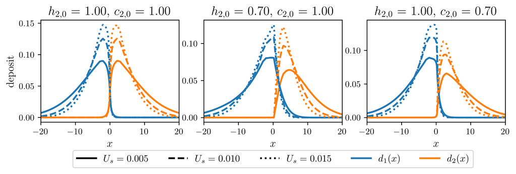

In most cases (with the exception of symmetric cases), the is a clear intrusion (encroachment?) of one current into another. This intrusion will be defined by identifying the collision point ($x_c$) and then tracking the deposited sediment beyond that point for each current. To analyze how the the deposits depend on the collision we will quantify two values, the mass ($\mu$) and the horizontal center of mass ($\eta$) of the intrusion. The intrusion mass is meant to quantify how much of the sediment from one current deposits beyond the collision point ($x_c$) into the region previously occuiped by the other current. The horizontal center of mass of the intrusion is mean to quantify how far the deposits (intrude) into the neighboring current.

The intrusion mass is defined by $$\mu=\int_{x_c}^{\infty} d_1(x) ~dx - \int_{-\infty}^{x_c} d_2(x) ~dx,$$ which is positive when current 1 intrudes into current 2 and negetive when current 2 intrudes into current 1. Numerically, the domain is $[a,b]=[-50,50]$ and in practice the integration is cut off at $[0.8a,0.8b]$ to avoid any integration of regions where the the front may have passed through the periodic boudary. The concentration at the front is negligible by the time it reaches the boundaries of the domain, but the integration region is reduced regardless.

For the horizontal center of mess, we first define $$D(x) = \begin{cases} d_2(x) & \text{if } x<x_c \\ d_1(x) & \text{if } x>x_c \end{cases},$$ which is the union of the two intrusions. Then, $$\eta = \frac{\int_{-\infty}^{\infty} x D(x) ~ dx}{\int_{x_c}^{\infty} d_1(x) ~dx + \int_{-\infty}^{x_c} d_2(x) ~dx}.$$ Values of $\eta\approx 0$ indicate the collision was mostly symmetric and any intrusion is mostly numerical diffusion. This definition combining the two intrusions ($D(x)$) was more robust handling symmetric and asymmetric cases. In the asymmetric case, a conditional statement on the sign of $\mu$ could be used to identify which direction the intrusion is going and then $\eta$ could be defined simply as the horizontal center of mass of that region. However, this fails in the case of symmetric collisions. Alternatively, we could take $$\eta = \frac{\int_{x_c}^{\infty} x d_1(x) ~dx}{\int_{x_c}^{\infty} d_1(x) ~dx} - \frac{\int_{-\infty}^{x_c} x d_2(x) ~dx}{\int_{-\infty}^{x_c} d_2(x) ~dx}.$$ Example plots showing the intrusions and $\mu$, $\eta$, $x_c$ are shown below. The values of the legend are for the asymmetric case, as $x_c = \eta = 0$ for the symmetric case.

We can see the settling speed is having little impact on the total intrusion mass, but lower settling speeds does result in farther $\eta$. This will be bore out in the full analysis and discussed later in this report.

## $U_s=0.005$

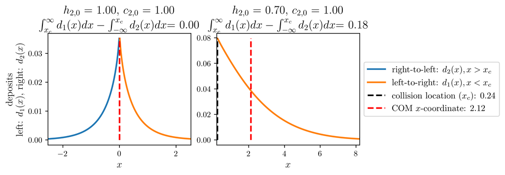

## $U_s=0.01$

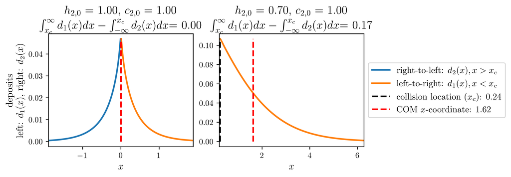

## $U_s=0.015$

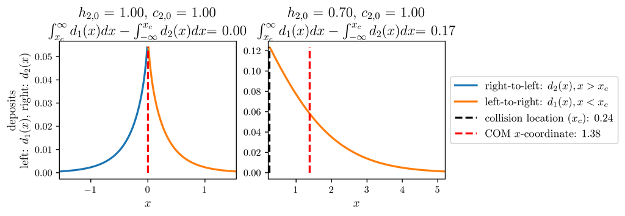

The final simulation time, $T=40$, was chosen such that a critical mass of sediment has deposited by that time. The following table shows the minimum and maximum amount of sediment deposited for each simulation as it depends on settling speed ($u_s$). That is, for $u_s=0.015$, the minimum amount of sediment deposited by the time $T=40$ is 94.2% across all tested $h_{2,0}$ and $c_{2,0}$.

**Table 1:** Percent of total mass deposited by the end of the simulation, i.e. $\displaystyle \frac{\int_a^b d_1(x) + d_2(x) ~dx}{h_{1,0}c_{1,0} + h_{2,0}c_{2,0}}$.

| $u_s$ | 0.005 | 0.01 | 0.015 |
| --- | --- | --- | --- |
| min | 95.0% | 97.8% | 94.2% |
| max | 97.0% | 98.1% | 99.0% |

## Collision summary statistics

The tables below give a range of the collision times and locations for varying settling speed.

**Table 2:** Collision location.

| $u_s$ | 0.005 | 0.01 | 0.015 |
| --- | --- | --- | --- |
| min | -0.02 | -0.02 | -0.02 |
| max | 0.44 | 0.44 | 0.46 |

**Table 3:** Collision times.

| $u_s$ | 0.005 | 0.01 | 0.015 |
| --- | --- | --- | --- |
| min | 1.482 | 1.494 | 1.506 |
| max | 1.796 | 1.816 | 1.844 |

## Results

Below are the plots for the intrusion mass and the horizontal center of mass. After the color plots, there are three-dimensional interactive plots. On each of the color plots the zero-contour is plotted in black, indicating where the shift is from current 1 intruding into current 2 or vise-versa. Notably, **current 1 is always more massive than current 2, but we can see here that in some cases (right of the contour) it is still possible for current to 2 to intrude into current 1**.

The plots look very similar, other than the scale. However, on the three-dimensional plots below you can identify distinct features.

There is some data missing in some plots (more missing for higher u_s). Some simulations blew up as the fronts collided after passing the periodic boundary condition. I think this is a result of the solutions being very small at this time in those regions and small oscillations at collision caused blow up. I think I have rectified this issue, but have not reran all the simulations at this time. There are two fixes to the issue:

1. Increase the domain an additional 10-15% to avoid any possibility of the fronts colliding a second time.
2. Absorbing boundary conditions. I implement absorbing boundary condtions along with the periodic condtions by drastically increasing the diffusion coefficient at the boudnary using a Gaussian. The fronts still pass through these regions and still collide, but it seems to prevent blow up (on the few test cases I have checked) and the fronts have been artifically smooothed by this point.

## $U_s=0.005$

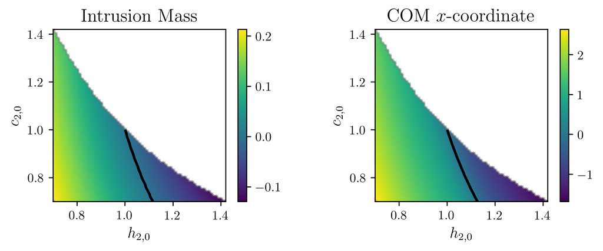

## $U_s=0.01$

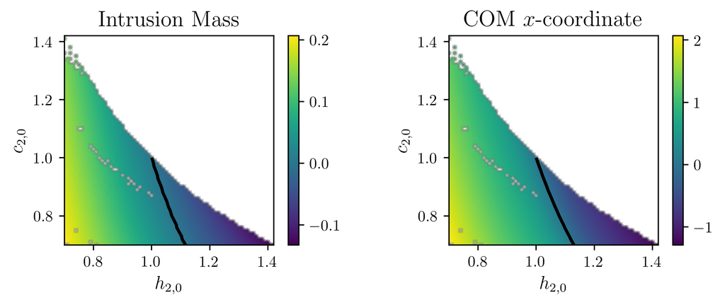

## $U_s=0.015$

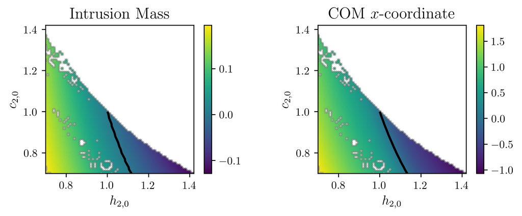

The plots below are the same date, just on a three-dimensional axis. In these plots, we can see that the intrusion mass is fairly linear, but the horizontal center of mass is not. Therefore, a linear approximation has been included for the intrustion mass. The planar approximations are listed below:

\begin{align} u_s = 0.005 & \quad p(h_{2,0},c_{2,0}) = -0.5196 h_{2,0} -0.1284 c_{2,0} + 0.6634, \\ u_s = 0.01 & \quad p(h_{2,0},c_{2,0}) = -0.5089 h_{2,0} -0.1297 c_{2,0} + 0.6523, \\ u_s = 0.015 & \quad p(h_{2,0},c_{2,0}) = -0.4845 h_{2,0} -0.1262 c_{2,0} + 0.6231. \end{align}

For the horizontal center of mass, There is a ''kink'' around the region where there is a sign change. This could be senstive to how this is defined and maybe it is worth it to try the alternative definition, $$\eta = \frac{\int_{x_c}^{\infty} x d_1(x) ~dx}{\int_{x_c}^{\infty} d_1(x) ~dx} - \frac{\int_{-\infty}^{x_c} x d_2(x) ~dx}{\int_{-\infty}^{x_c} d_2(x) ~dx}.$$

[interactive chart not shown]

In the plots below, we have plotted the intrusion mass and horiztonal center of mass for all three settling speeds on the same plot. As stated previously, the intrusion mass has negligible dependence on settling speed. This makes sense as$\ldots$

1. The collision times, $\approx 1.5$ to $2$, (shown below) are less than 5% of the full simulation.
2. Most of the sediment is still suspended at the time of collision
3. Since both currents have the same $u_s$, for a fixed $h_{2,0}$ and $c_{2,0}$ the collision will be nearly identical as $u_s$ is varied.
4. Therefore, we have same amount of sediment, with the same collision dynamics, it follows that the intrusion mass will stay relatively unchanged.

Why does the horizontal center of mass show stronger dependence on $u_s$ then? The above arguement just say the relative mass will intrude from one current to the other, but with slower settling speed, the sediment stays suspened longer, and has more time to intrude farther into the neighboring current.

[interactive chart not shown]